# Semantic Analytical Database Fact Metrics Grouping

## Why Metrics Need to be Grouped

There is a whopping of 2387 metrics created for end user to use (In addition there are 3000 + hidden metrics to support all the calculations). With such a rich set of metrics available, it is overwhelming for the end users to find the needed metrics.

DS is proposing the metric grouping structures. We are proposing a maximum of 3 level grouping structure as below:

**Level 1 Group –> Level 2 Group –> Leaf Level: Metrics**

DS is proposing to fix the level 1 group based on metrics functions, like Domestic/Exporting, Brick&Mortar/Online, Retail/Grocery etc. Currently, we have 9 function groups defined as below:

1. Base Metrics
2. Baseline /Incremental / Lost
3. Brick & Mortar / Online
4. Distribution Metrics
5. Domestic / Export
6. Pack Ranging Metrics
7. Promo / Non Promo
8. Retail / Grocery
9. Scanout / Sellin

if a function group is not subscribed by a client, then we will not make these metrics available to the client.

The level 2 has many different grouping options, we will need your opinion to pick the best one for the end user to use. The guideline is the group meaning should be easily grasped by end users and the members of metrics in each group should be displayed in Excel workbook with no scrolling (if possible). DS has proposed the below 5 options:

- Option 1
  - Further breakdown the function to the subfunction groups, like Domestic and Exporting
- Option 2
  - Amount Metrics
  - Price Metrics
  - Unit Metrics
- Option 3
  - Current Metrics (Main metrics including some common last year related like growth, EI)
  - LY or YoY (Last year and year over year)
  - PP or PoP (Last period and period over period)
- Option 4 (The combination of 2 & 3)
  - Current Metrics (Amount)
  - Current Metrics (Price)
  - Current Metrics (Unit)
  - LY or YoY (Amount)
  - LY or YoY (Price)
  - LY or YoY (Unit)
  - PP or PoP (Amount)
  - PP or PoP (Price)
  - PP or PoP (Unit)
- Option 5
  - Customised grouping based on a client’s own preference.
  - The additional fee should apply, suggested fee for this purpose is: $1500

The proceeding sections will give you a detail hierarchical view of each option.

## Metric Grouping Option 1

[interactive chart not shown]

## Metric Grouping Option 2

[interactive chart not shown]

## Metric Grouping Option 3

[interactive chart not shown]

## Metric Grouping Option 4

[interactive chart not shown]

## Actual Metric Grouping User End Example

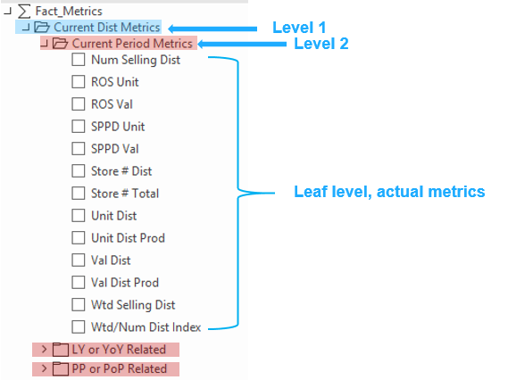

## Please Give us Your Suggestion

DS team prefers the Option 4 since that this is the most granular with fewer members and the level 2 grouping should be easy to understand as well.

Which grouping option do you think is a better suit for end user needs?

Or do you have a better grouping idea?

We are looking forward to your advice before we release it to the client.

**Thank you !!**

[output not shown]

[output not shown]

[output not shown]